# Dimensionality Reduction Methods

## Part I: Research Question

Can we predict identify the principal variables of the customers using PCA?

We will answer this question using principal component analysis (PCA).

The goal of this data analysis is to find if we can identify the principal variables of the customers.

## Part II: Method Justification

PCAs aim is to reduce a larger set of variables into a smaller set of 'artificial' variables, called 'principal components', which account for most of the variance in the original variables. We would assume that PCA will find the most important components and the amount of components that matter the most, for example in this dataset, we would assume that out of all the variables we run PCA on, it will find out the most imprtant components in the set. PCA will analyze this dataset by splitting the continuous variables that we choose into smaller components. We will then analyze the variance of these components to find the components that matter the most to the overall analysis and dataset.

An assumption of PCA is that there needs to be a linear relationship between all variables.

## Part III: Data Preparation

The continuous variables we will be using are Outage_sec_perweek, Email,Contacts,Yearly_equip_failure,Tenure,MonthlyCharge,Bandwidth_GB_Year

```python
# Importing packages to be used
import numpy as np
# numpy for data analysis functionality
import pandas as pd
# pandas for dataframes
from sklearn.decomposition import PCA
# PCA classifier
# Import ElbowVisualizer
from yellowbrick.cluster import KElbowVisualizer
import matplotlib.pyplot as plt
%matplotlib inline
# matplotlib for plotting
import seaborn as sns
# seaborn for extra plotting functionality
```

```python
# Importing the data
df = pd.read_csv('Churn Data\churn_clean.csv')
```

```python
# Creating new dataframe with only the values we need
newdf = df[['Outage_sec_perweek', 'Email', 'Contacts','Yearly_equip_failure','Tenure','MonthlyCharge','Bandwidth_GB_Year']].copy()
```

```python
newdf
```

|  | Outage_sec_perweek | Email | Contacts | Yearly_equip_failure | Tenure | MonthlyCharge | Bandwidth_GB_Year |
| --- | --- | --- | --- | --- | --- | --- | --- |
| 0 | 7.978323 | 10 | 0 | 1 | 6.795513 | 172.455519 | 904.536110 |
| 1 | 11.699080 | 12 | 0 | 1 | 1.156681 | 242.632554 | 800.982766 |
| 2 | 10.752800 | 9 | 0 | 1 | 15.754144 | 159.947583 | 2054.706961 |
| 3 | 14.913540 | 15 | 2 | 0 | 17.087227 | 119.956840 | 2164.579412 |
| 4 | 8.147417 | 16 | 2 | 1 | 1.670972 | 149.948316 | 271.493436 |
| ... | ... | ... | ... | ... | ... | ... | ... |
| 9995 | 9.415935 | 12 | 2 | 0 | 68.197130 | 159.979400 | 6511.252601 |
| 9996 | 6.740547 | 15 | 2 | 0 | 61.040370 | 207.481100 | 5695.951810 |
| 9997 | 6.590911 | 10 | 0 | 0 | 47.416890 | 169.974100 | 4159.305799 |
| 9998 | 12.071910 | 14 | 1 | 0 | 71.095600 | 252.624000 | 6468.456752 |
| 9999 | 11.754720 | 17 | 1 | 0 | 63.350860 | 217.484000 | 5857.586167 |

10000 rows × 7 columns

```python
# Scaling the data
from sklearn.preprocessing import StandardScaler
from sklearn import preprocessing

num_cols = newdf.columns[newdf.dtypes.apply(lambda c: np.issubdtype(c, np.number))]

scaler = StandardScaler()

newdf[num_cols] = scaler.fit_transform(newdf[num_cols])
```

```python
newdf
```

|  | Outage_sec_perweek | Email | Contacts | Yearly_equip_failure | Tenure | MonthlyCharge | Bandwidth_GB_Year |
| --- | --- | --- | --- | --- | --- | --- | --- |
| 0 | -0.679978 | -0.666282 | -1.005852 | 0.946658 | -1.048746 | -0.003943 | -1.138487 |
| 1 | 0.570331 | -0.005288 | -1.005852 | 0.946658 | -1.262001 | 1.630326 | -1.185876 |
| 2 | 0.252347 | -0.996779 | -1.005852 | 0.946658 | -0.709940 | -0.295225 | -0.612138 |
| 3 | 1.650506 | 0.986203 | 1.017588 | -0.625864 | -0.659524 | -1.226521 | -0.561857 |
| 4 | -0.623156 | 1.316700 | 1.017588 | 0.946658 | -1.242551 | -0.528086 | -1.428184 |
| ... | ... | ... | ... | ... | ... | ... | ... |
| 9995 | -0.196888 | -0.005288 | 1.017588 | -0.625864 | 1.273401 | -0.294484 | 1.427298 |
| 9996 | -1.095915 | 0.986203 | 1.017588 | -0.625864 | 1.002740 | 0.811726 | 1.054194 |
| 9997 | -1.146198 | -0.666282 | -1.005852 | -0.625864 | 0.487513 | -0.061729 | 0.350984 |
| 9998 | 0.695616 | 0.655706 | 0.005868 | -0.625864 | 1.383018 | 1.863005 | 1.407713 |
| 9999 | 0.589028 | 1.647197 | 0.005868 | -0.625864 | 1.090120 | 1.044672 | 1.128163 |

10000 rows × 7 columns

```python
# export file to csv
newdf.to_csv('cleaned_data2.csv', index = False)
```

## Part IV: Analysis

```python
# Creating covarience matrix
newdf.cov()
```

|  | Outage_sec_perweek | Email | Contacts | Yearly_equip_failure | Tenure | MonthlyCharge | Bandwidth_GB_Year |
| --- | --- | --- | --- | --- | --- | --- | --- |
| Outage_sec_perweek | 1.000100 | 0.003994 | 0.015093 | 0.002909 | 0.002932 | 0.020498 | 0.004176 |
| Email | 0.003994 | 1.000100 | 0.003041 | -0.016356 | -0.014469 | 0.001997 | -0.014581 |
| Contacts | 0.015093 | 0.003041 | 1.000100 | -0.006033 | 0.002820 | 0.004259 | 0.003299 |
| Yearly_equip_failure | 0.002909 | -0.016356 | -0.006033 | 1.000100 | 0.012436 | -0.007173 | 0.012035 |
| Tenure | 0.002932 | -0.014469 | 0.002820 | 0.012436 | 1.000100 | -0.003337 | 0.991594 |
| MonthlyCharge | 0.020498 | 0.001997 | 0.004259 | -0.007173 | -0.003337 | 1.000100 | 0.060412 |
| Bandwidth_GB_Year | 0.004176 | -0.014581 | 0.003299 | 0.012035 | 0.991594 | 0.060412 | 1.000100 |

```python
# Creating PCA dataframe
pca = PCA(n_components=7)
Principal_components=pca.fit_transform(newdf)
pca_df = pd.DataFrame(data = Principal_components, columns = ['PC 1', 'PC 2', 'PC 3', 'PC 4', 'PC 5', 'PC 6','PC 7'])
print(pca_df)
```

```
          PC 1      PC 2      PC 3      PC 4      PC 5      PC 6      PC 7
0    -1.523075 -1.324725  0.639004 -0.772419  0.017402  0.355159 -0.064702
1    -1.647095  0.468706  1.126523 -1.780499  0.452760  0.559299 -0.021650
2    -0.911359 -1.069899  1.153518 -0.606681  0.179703 -0.467084  0.081535
3    -0.929418  1.252127 -0.368282  1.460092  0.985739 -1.301066  0.123971
4    -1.917807 -0.050066 -0.348914  1.143068  1.115378  1.245560 -0.108910
...        ...       ...       ...       ...       ...       ...       ...
9995  1.888065  0.350785 -0.485788  1.001109 -0.519615  0.009032  0.123703
9996  1.452264  0.763278 -1.213297  0.347134 -0.425336  1.382520  0.000887
9997  0.581291 -1.132842 -0.660076 -0.756868 -0.936547 -0.101231 -0.093087
9998  2.026127  1.776729 -0.179158 -1.111570 -0.117250  0.350902 -0.065042
9999  1.567387  1.609137 -0.958391 -0.636461  0.747906  0.273986 -0.018688

[10000 rows x 7 columns]
```

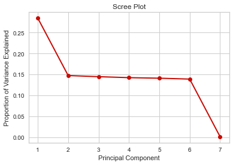

```python
# Creating Scree Plot
PC_values = np.arange(pca.n_components_) + 1
plt.plot(PC_values, pca.explained_variance_ratio_, 'ro-', linewidth=2)
plt.title('Scree Plot')
plt.xlabel('Principal Component')
plt.ylabel('Proportion of Variance Explained')
plt.show()
```

This Scree Plot shows that the most important principal components are the first six, and it drops to 0 at number seven.

```python
print ("Proportion of Variance Explained : ", pca.explained_variance_ratio_)

out_sum = np.cumsum(pca.explained_variance_ratio_)
print ("Cumulative Prop. Variance Explained: ", out_sum)
```

```
Proportion of Variance Explained :  [0.28484473 0.1473728  0.14464233 0.14231428 0.14101223 0.13889102
 0.00092261]
Cumulative Prop. Variance Explained:  [0.28484473 0.43221753 0.57685986 0.71917414 0.86018637 0.99907739
 1.        ]
```

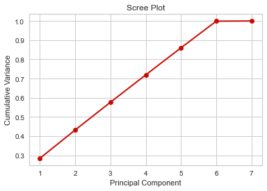

```python
# Creating Scree Plot
PC_values = np.arange(pca.n_components_) + 1
plt.plot(PC_values, out_sum, 'ro-', linewidth=2)
plt.title('Scree Plot')
plt.xlabel('Principal Component')
plt.ylabel('Cumulative Variance')
plt.show()
```

Graphing the cumulative variance of the components

```python
print(pca.explained_variance_)
```

```
[1.9941125  1.03171277 1.01259757 0.99629962 0.98718433 0.97233439
 0.00645889]
```

```python
loadings = pd.DataFrame(pca.components_.T, columns=['PC1', 'PC2', 'PC3', 'PC4', 'PC5', 'PC6','PC 7'], index=newdf.columns)
loadings
```

|  | PC1 | PC2 | PC3 | PC4 | PC5 | PC6 | PC 7 |
| --- | --- | --- | --- | --- | --- | --- | --- |
| Outage_sec_perweek | 0.005923 | 0.561201 | 0.428800 | -0.019521 | 0.329927 | -0.626032 | 0.000049 |
| Email | -0.020808 | 0.325213 | -0.586632 | -0.005922 | 0.695650 | 0.256326 | 0.000189 |
| Contacts | 0.004442 | 0.431953 | 0.121625 | 0.801237 | -0.214876 | 0.332343 | -0.000152 |
| Yearly_equip_failure | 0.017426 | -0.328135 | 0.643991 | 0.045340 | 0.539020 | 0.429769 | -0.000056 |
| Tenure | 0.705592 | -0.027298 | -0.031242 | 0.033069 | 0.019123 | -0.030203 | -0.705725 |
| MonthlyCharge | 0.040567 | 0.533143 | 0.202925 | -0.595339 | -0.264831 | 0.496299 | -0.045358 |
| Bandwidth_GB_Year | 0.706897 | 0.006897 | -0.017962 | -0.005007 | 0.001886 | 0.001772 | 0.707033 |